# Topic models: STM

Pablo Barbera

August 9, 2017

Most text corpora have not only the documents per se, but also a lot of metadata associated – we know the author, characteristics of the author, when the document was produced, etc. The structural topic model takes advantage of this metadata to improve the discovery of topics. Here we will learn how it works, how we can interpret the output, and some issues related to its usage for research.

The running example will be all the posts published on the Facebook pages of Senators in the U.S. Congress between 2013 and 2014, which you just worked with. But note here that we group the posts in a different way: each document corresponds to posts on a specific day and party. Why? It better captures the assumptions behind the LDA model.

```r
library(readtext)
fb <- readtext(file='../data/facebook/*.txt')
# creating corpus object
library(quanteda)
fb <- corpus(fb)
summary(fb)
```

```
## Corpus consisting of 1427 documents, showing 100 documents.
##
##              Text Types Tokens Sentences
##  D_2013-01-02.txt   546   1178        53
##  D_2013-01-03.txt   489   1133        51
##  D_2013-01-04.txt   383    769        37
##  D_2013-01-05.txt    38     44         1
##  D_2013-01-07.txt   375    817        42
##  D_2013-01-08.txt   165    266        18
##  D_2013-01-09.txt   352    590        24
##  D_2013-01-10.txt   474    968        42
##  D_2013-01-11.txt   478    915        37
##  D_2013-01-12.txt    59     78         2
##  D_2013-01-13.txt    49     61         3
##  D_2013-01-14.txt   339    582        23
##  D_2013-01-15.txt   331    570        21
##  D_2013-01-16.txt   777   1838        77
##  D_2013-01-17.txt   331    588        26
##  D_2013-01-18.txt   345    610        32
##  D_2013-01-19.txt   150    243         9
##  D_2013-01-20.txt   140    272        12
##  D_2013-01-21.txt   247    466        23
##  D_2013-01-22.txt   549   1132        54
##  D_2013-01-23.txt   733   1723        67
##  D_2013-01-24.txt   864   2073        95
##  D_2013-01-25.txt   612   1282        53
##  D_2013-01-26.txt   172    275        15
##  D_2013-01-27.txt   206    329        16
##  D_2013-01-28.txt   572   1260        59
##  D_2013-01-29.txt   903   2428        95
##  D_2013-01-30.txt   733   1749        83
##  D_2013-01-31.txt   625   1257        59
##  D_2013-02-01.txt   738   1561        60
##  D_2013-02-02.txt    41     46         2
##  D_2013-02-03.txt    54     70         5
##  D_2013-02-04.txt   605   1331        67
##  D_2013-02-05.txt   455    851        43
##  D_2013-02-06.txt   568   1128        46
##  D_2013-02-07.txt   786   1600        76
##  D_2013-02-08.txt   486   1028        57
```

[output cut: 52 more lines]

```
##  D_2013-04-08.txt   407    746        26
##  D_2013-04-09.txt   787   2134        98
##  D_2013-04-10.txt   953   2395       109
##  D_2013-04-11.txt   659   1491        57
##  D_2013-04-12.txt   608   1272        48
##  D_2013-04-13.txt   104    149         5
##  D_2013-04-14.txt   226    407        16
##  D_2013-04-15.txt   544   1220        59
##  D_2013-04-16.txt   620   1249        56
##  D_2013-04-17.txt   871   2155        94
##  D_2013-04-18.txt   916   2418       100
##
## Source:  /home/rstudio/day3/* on x86_64 by rstudio
## Created: Wed Aug  9 13:27:46 2017
## Notes:
```

Constructing the DFM and looking at the most frequent features…

```r
# constructing DFM
fbdfm <- dfm(fb, remove_numbers=TRUE, remove_punct=TRUE, verbose=TRUE,
              remove_url=TRUE, remove=stopwords("english"))
fbdfm <- dfm_trim(fbdfm, min_docfreq = 5)
save(fbdfm, file="../backup/fb-dfm.Rdata")
```

```r
load("../backup/fb-dfm.Rdata")
topfeatures(fbdfm, n=25)
```

```
##       will      today     senate    senator        new        can
##       8983       7875       5538       5423       4456       4105
##       bill      state  president       work      great        u.s
##       3981       3771       3719       3348       3341       3338
##   veterans       help   national     people        day   american
##       3043       3011       2994       2952       2939       2891
##       time     health        act       need    federal        one
##       2826       2793       2785       2732       2668       2649
## government
##       2639
```

Let’s run the standard LDA just to see what we get…

```r
# running LDA
library(topicmodels)
K <- 50
lda <- LDA(fbdfm, k = K, method = "Gibbs",
                control = list(verbose=25L, seed = 123,
                    burnin = 100, iter = 400))
save(lda, file="../backup/lda-output.Rdata")
```

```r
library(topicmodels)
load("../backup/lda-output.Rdata")
terms <- get_terms(lda, 15)
terms
```

```
##       Topic 1    Topic 2     Topic 3       Topic 4    Topic 5
##  [1,] "pipeline" "air"       "immigration" "north"    "president"
##  [2,] "keystone" "force"     "border"      "dakota"   "will"
##  [3,] "today"    "national"  "bill"        "today"    "obama"
##  [4,] "jobs"     "base"      "security"    "state"    "congress"
##  [5,] "energy"   "today"     "will"        "help"     "president's"
##  [6,] "will"     "year"      "amendment"   "make"     "executive"
##  [7,] "xl"       "can"       "reform"      "can"      "people"
##  [8,] "need"     "guard"     "read"        "great"    "law"
##  [9,] "project"  "work"      "immigrants"  "work"     "american"
## [10,] "american" "one"       "illegal"     "service"  "obama's"
## [11,] "state"    "support"   "enforcement" "west"     "senate"
## [12,] "oil"      "important" "gang"        "dakotans" "new"
## [13,] "can"      "new"       "one"         "dakota's" "action"
## [14,] "approve"  "grand"     "legal"       "across"   "u.s"
```

[output cut: 161 more lines]

Now we will extract the metadata from the file names:

```r
# creating metadata
library(stringr)
features <- str_split(docnames(fbdfm), "_")
repub <- unlist(lapply(features, '[', 1))
```

And we’re ready to run `stm`!

```r
library(stm)
stm <- stm(documents=fbdfm, K=30, prevalence=~repub, max.em.its=50)
save(stm, file="../backup/stm-output.Rdata")
```

`stm` offers a series of features to explore the output. First, just like LDA, we can look at the words that are most associated with each topic.

```r
library(stm)
load("../backup/stm-output.Rdata")
# looking at a few topics
labelTopics(stm, topics=1)
```

```
## Topic 1 Top Words:
##       Highest Prob: will, senator, today, students, work, affordable, make
##       FREX: donnelly, hawai'i, schatz, baltimore, affordable, leahy, mikulski
##       Lift: greenbelt, tempore, #unemployment, foreclosure, hoyer, #sequestration, reed-heller
##       Score: donnelly, will, senator, schatz, insurance, shaheen, hawai'i
```

```r
labelTopics(stm, topics=4)
```

```
## Topic 4 Top Words:
##       Highest Prob: will, students, united, human, ukraine, world, support
##       FREX: ukraine, russia, russian, putin, ukrainian, russia's, china
##       Lift: ukraine's, crimea, ukraine, vladimir, ukrainian, #leapact, ukrainians
##       Score: ukraine, russia, will, putin, russian, students, keystone
```

```r
labelTopics(stm, topics=5)
```

```
## Topic 5 Top Words:
##       Highest Prob: veterans, will, military, honor, country, war, must
##       FREX: veterans, veteran, marine, war, earned, clinic, served
##       Lift: armistice, homelessness, g.i, veterans, veteran, one-stop, psychological
##       Score: veterans, military, honor, will, war, veteran, served
```

```r
labelTopics(stm, topics=7)
```

```
## Topic 7 Top Words:
##       Highest Prob: day, happy, family, time, us, today, celebrate
##       FREX: christmas, holiday, happy, thanksgiving, celebrate, wishing, thankful
##       Lift: thanksgiving, #thanksgiving, hanukkah, merry, ringing, blessings, thatcher
##       Score: thanksgiving, christmas, holiday, happy, day, celebrate, merry
```

```r
labelTopics(stm, topics=9)
```

```
## Topic 9 Top Words:
##       Highest Prob: act, violence, state, sexual, domestic, victims, also
##       FREX: domestic, violence, sexual, mayor, abuse, assault, victims
##       Lift: fafsa, postmaster, domestic, uprising, derry, 1990s, stalking
##       Score: violence, domestic, sexual, victims, act, vawa, assault
```

But unlike LDA, we now can estimate the effects of the features we considered into the prevalence of different topics

```r
# effects
est <- estimateEffect(~repub, stm,
    uncertainty="None")
summary(est, topics=1)
```

[output not shown]

```r
summary(est, topics=4)
```

```
##
## Call:
## estimateEffect(formula = ~repub, stmobj = stm, uncertainty = "None")
##
##
## Topic 4:
##
## Coefficients:
##             Estimate Std. Error t value Pr(>|t|)
## (Intercept) 0.012036   0.001156  10.414  < 2e-16 ***
## repubR      0.011763   0.001529   7.694 2.64e-14 ***
## ---
## Signif. codes:  0 '***' 0.001 '**' 0.01 '*' 0.05 '.' 0.1 ' ' 1
```

```r
summary(est, topics=5)
```

```
##
## Call:
## estimateEffect(formula = ~repub, stmobj = stm, uncertainty = "None")
##
##
## Topic 5:
##
## Coefficients:
##              Estimate Std. Error t value Pr(>|t|)
## (Intercept)  0.036452   0.001537   23.71  < 2e-16 ***
## repubR      -0.009546   0.002117   -4.51 7.02e-06 ***
## ---
## Signif. codes:  0 '***' 0.001 '**' 0.01 '*' 0.05 '.' 0.1 ' ' 1
```

```r
summary(est, topics=7)
```

```
##
## Call:
## estimateEffect(formula = ~repub, stmobj = stm, uncertainty = "None")
##
##
## Topic 7:
##
## Coefficients:
##             Estimate Std. Error t value Pr(>|t|)
## (Intercept) 0.054428   0.004271  12.743   <2e-16 ***
## repubR      0.001705   0.005940   0.287    0.774
## ---
## Signif. codes:  0 '***' 0.001 '**' 0.01 '*' 0.05 '.' 0.1 ' ' 1
```

```r
summary(est, topics=9)
```

```
##
## Call:
## estimateEffect(formula = ~repub, stmobj = stm, uncertainty = "None")
##
##
## Topic 9:
##
## Coefficients:
##              Estimate Std. Error t value Pr(>|t|)
## (Intercept)  0.029251   0.001091  26.814  < 2e-16 ***
## repubR      -0.009188   0.001521  -6.039 1.97e-09 ***
## ---
## Signif. codes:  0 '***' 0.001 '**' 0.01 '*' 0.05 '.' 0.1 ' ' 1
```

Let’s say we’re interested in finding the most partisan topics. How would we do this?

```r
# let's look at the structure of the output object...
names(est)
```

```
## [1] "parameters"  "topics"      "call"        "uncertainty" "formula"
## [6] "data"        "modelframe"  "varlist"
```

```r
length(est$parameters)
```

```
## [1] 30
```

```r
est$parameters[[1]]
```

```
## [[1]]
## [[1]]$est
## (Intercept)      repubR
##  0.07472072 -0.07028811
##
## [[1]]$vcov
##              [,1]          [,2]
## [1,]  2.95091e-06 -2.950910e-06
## [2,] -2.95091e-06  5.784269e-06
```

```r
# aha!
coef <- se <- rep(NA, 30)
for (i in 1:30){
    coef[i] <- est$parameters[[i]][[1]]$est[2]
    se[i] <- sqrt(est$parameters[[i]][[1]]$vcov[2,2])
}

df <- data.frame(topic = 1:30, coef=coef, se=se)
head(df[order(df$coef),])
```

```
##    topic        coef          se
## 16    16 -0.09319774 0.002267677
## 1      1 -0.07028811 0.002405051
## 26    26 -0.06496722 0.002279952
## 8      8 -0.05888052 0.003759007
## 22    22 -0.04971407 0.002183726
## 24    24 -0.04101892 0.002528858
```

```r
tail(df[order(df$coef),])
```

```
##    topic       coef           se
## 29    29 0.03612237 0.0012056767
## 17    17 0.03949522 0.0009631586
## 2      2 0.04316019 0.0012074216
## 20    20 0.04935212 0.0034374509
## 12    12 0.06538355 0.0035287521
## 11    11 0.06627094 0.0032888583
```

```r
labelTopics(stm, topics=16)
```

```
## Topic 16 Top Words:
##       Highest Prob: new, national, mexico, work, make, west, women
##       FREX: mexico, virginia's, connecticut, virginia, virginians, west, delawareans
##       Lift: #keepitpublic, valles, caldera, malloy, wheeling, rican, #nytownoftheday
##       Score: mexico, virginia, rhode, virginians, connecticut, new, virginia's
```

```r
labelTopics(stm, topics=1)
```

```
## Topic 1 Top Words:
##       Highest Prob: will, senator, today, students, work, affordable, make
##       FREX: donnelly, hawai'i, schatz, baltimore, affordable, leahy, mikulski
##       Lift: greenbelt, tempore, #unemployment, foreclosure, hoyer, #sequestration, reed-heller
##       Score: donnelly, will, senator, schatz, insurance, shaheen, hawai'i
```

```r
labelTopics(stm, topics=26)
```

```
## Topic 26 Top Words:
##       Highest Prob: north, help, state, can, u.s, new, businesses
##       FREX: climate, businesses, dakota, north, small, hampshire, forks
##       Lift: dimensions, berthold, captions, cropped, firefighting, annapolis, ny's
##       Score: dakota, north, help, businesses, state, small, business
```

```r
labelTopics(stm, topics=8)
```

```
## Topic 8 Top Words:
##       Highest Prob: senator, gun, senate, committee, rights, watch, hearing
##       FREX: gun, newtown, que, de, y, 150th, countdown
##       Lift: año, derechos, ha, high-capacity, magazines, más, migratoria
##       Score: gun, violence, que, senator, wv's, countdown, senate
```

```r
labelTopics(stm, topics=11)
```

```
## Topic 11 Top Words:
##       Highest Prob: kansas, thanks, meeting, great, dr, morning, one
##       FREX: ppl, club, luther, king, rotary, ovr, olathe
##       Lift: clarion, worland, #savesaeed, pastors, mahoning, admin's, pipe
##       Score: kansas, luther, alaska, uni, ppl, tennessee, #idpol
```

```r
labelTopics(stm, topics=12)
```

```
## Topic 12 Top Words:
##       Highest Prob: will, irs, great, news, texas, good, cornyn
##       FREX: irs, abt, egypt, targeting, tx, qs, chattanooga
##       Lift: papers, gaymarriage, eparegs, fiscalcliff, gorham, #unipanthers, sterrett
##       Score: irs, cornyn, texas, will, uni, conservative, corker
```

```r
labelTopics(stm, topics=20)
```

```
## Topic 20 Top Words:
##       Highest Prob: obamacare, health, will, government, care, insurance, can
##       FREX: obamacare, #obamacare, defund, shutdown, premiums, mandate, exchanges
##       Lift: defunds, #harryreidsshutdown, o-care, navigator, #yourstory, republican.senate.gov, yourstory
##       Score: obamacare, shutdown, insurance, defund, #obamacare, health, care
```

```r
labelTopics(stm, topics=2)
```

```
## Topic 2 Top Words:
##       Highest Prob: today, senate, will, committee, senator, na, washington
##       FREX: sessions, constitution, grassley, white, carolina, hannity, tennessee
##       Lift: boeing's, bailout, arizona's, versions, titus, stratcom's, heck
##       Score: rubio, senate, committee, sessions, alaska, today, grassley
```

Let’s now try running a slightly more complex example with two features as metadata: day and party. Now we’ll make both the prevalence and content a function of these variables.

```r
# metadata into a data frame
library(stringr)
features <- str_split(docnames(fbdfm), "_")
repub <- unlist(lapply(features, '[', 1))
date <- as.Date(
    gsub('.txt', '',
        unlist(lapply(features, '[', 2))))
meta <- data.frame(date=as.numeric(date), repub=repub)
```

```r
# another (shorter) run
stm <- stm(documents=fbdfm, K=30, prevalence=~repub+s(date),
    max.em.its=50, content=~repub, data=meta)

save(stm, file="../backup/stm-small-output.Rdata")
```

`stm` offers other functions to explore how content varies as a function of covariates. Let’s take a look.

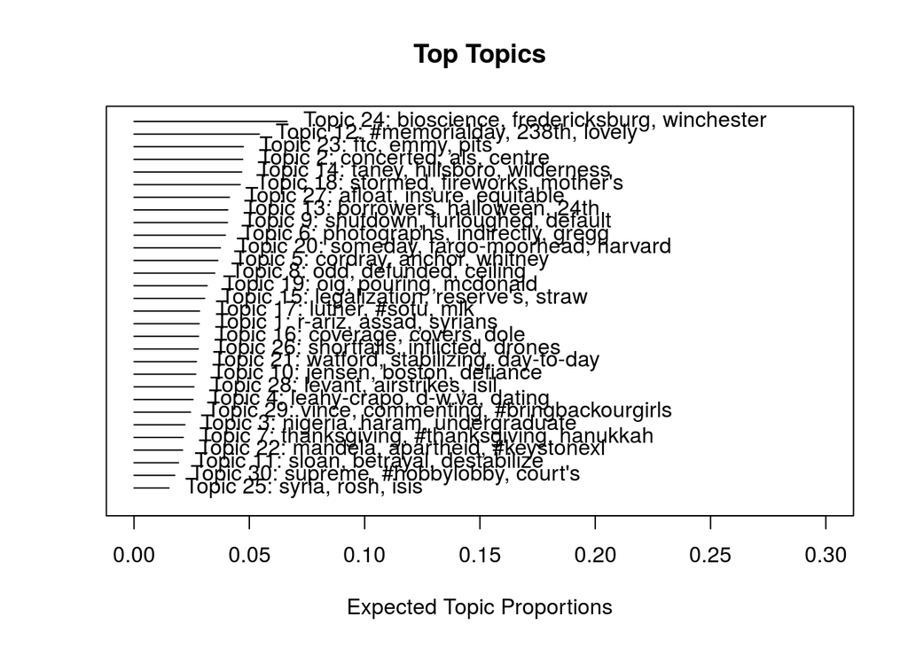

```r
library(stm)
load("../backup/stm-small-output.Rdata")

# summary
plot(stm, type = "summary", xlim = c(0, .3))
```

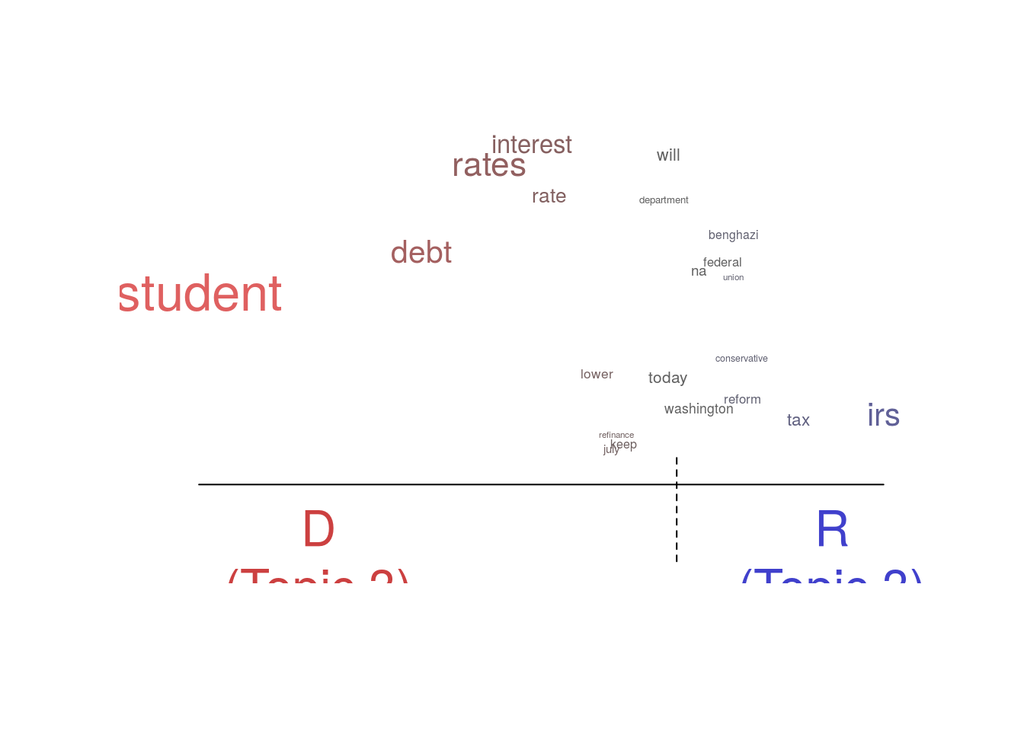

```r
# how republicans (TRUE) use topics differently
plot(stm, type = "perspectives", topics = 3)
```

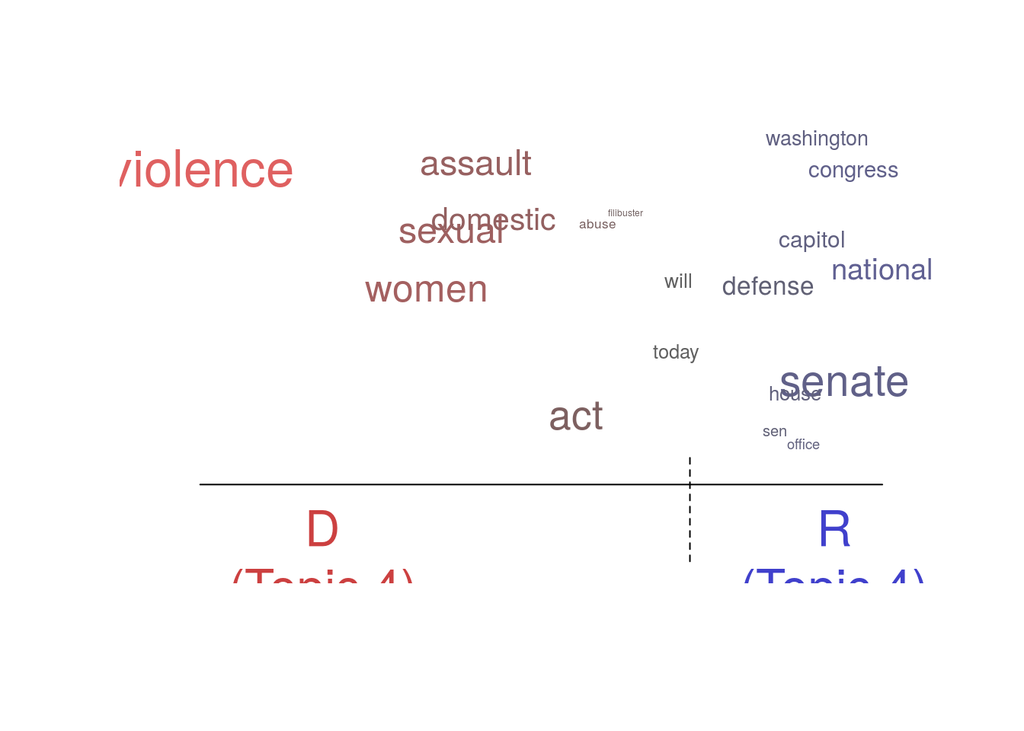

```r
plot(stm, type = "perspectives", topics = 4)
```

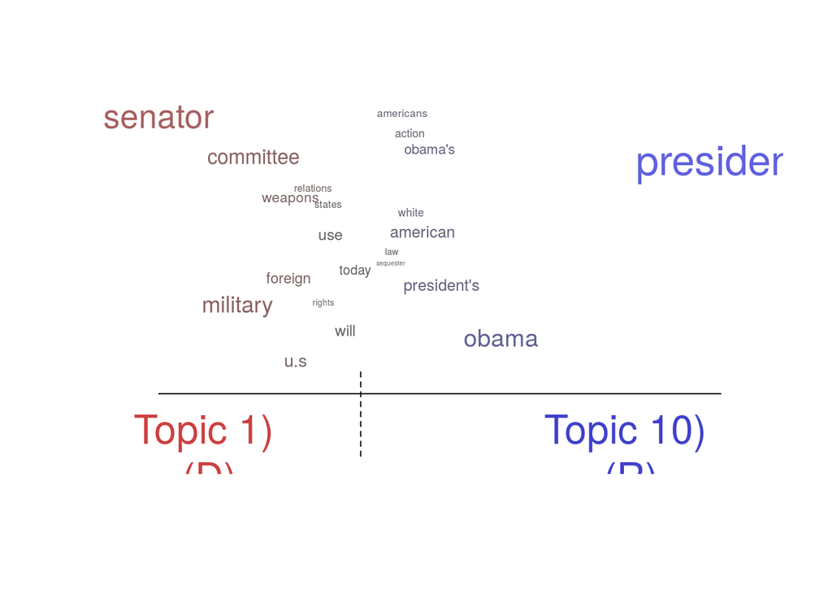

```r
plot(stm, type = "perspectives", topics = c(1,10))
```

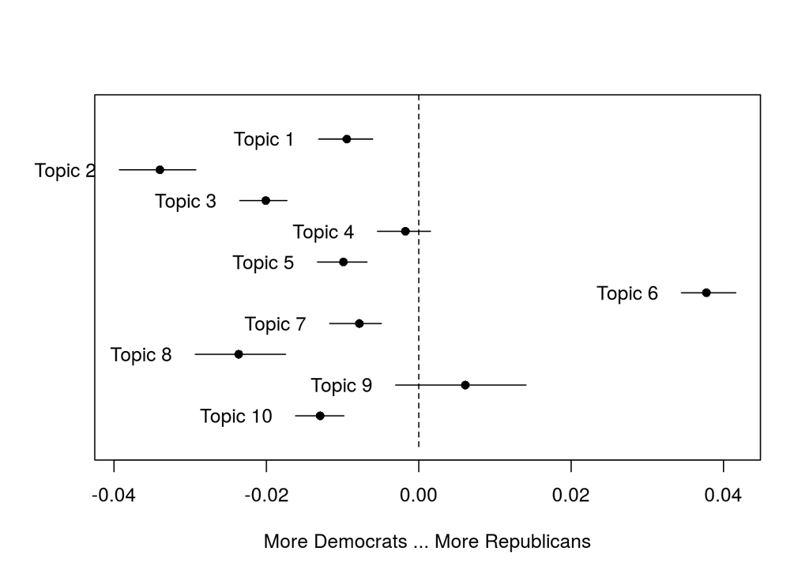

```r
# prevalence over time
est <- estimateEffect(~s(date)+repub,
    stm, uncertainty = "None", meta=meta)

plot(est, covariate="repub", topics=1:10,
    model=stm, method="difference",
    cov.value1="D", cov.value2="R",
    xlab = "More Democrats ... More Republicans",
    labeltype="custom", custom.labels=paste("Topic", 1:10))
```

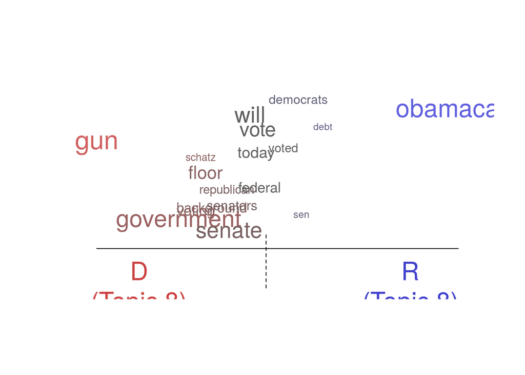

```r
plot(stm, type = "perspectives", topics = 8)
```

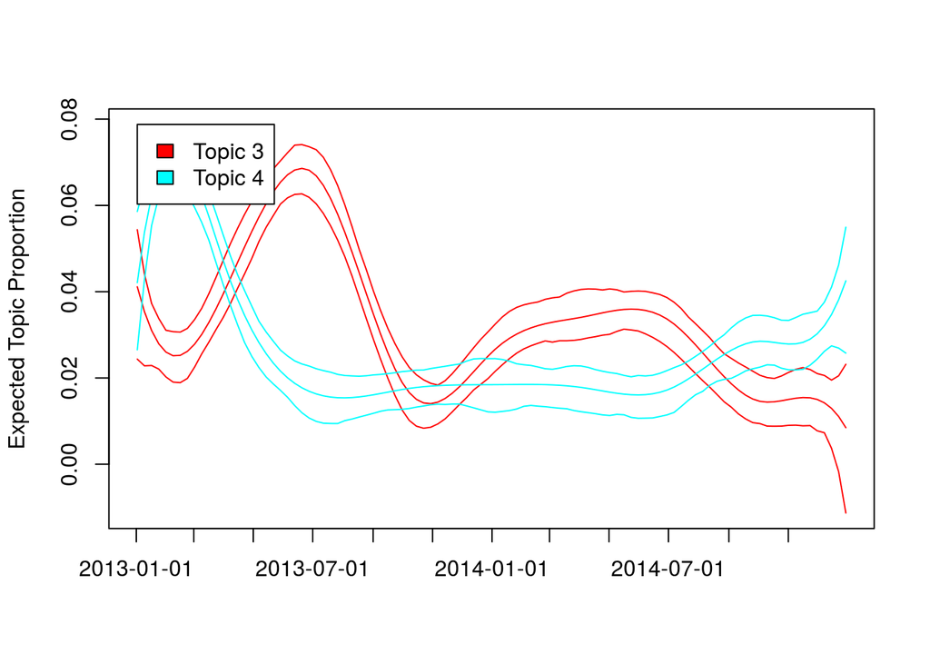

```r
plot(est, "date", method="continuous", topics=3:4,
    xaxt="n")
dates <- seq(from = as.Date("2013-01-01"), to = as.Date("2014-12-31"), by="2 months")
axis(1, at = dates, dates)
```